# task10

Edgaras Petrauskas

Sunday, April 24, 2016

**[@Hyndman2014a, ch. 3., Lab Session 3]**

1. For this exercise, use the price of a dozen eggs in the United States from 1900–1993 (data set eggs). Experiment with the various options in the holt() function to see how much the forecasts change with damped or exponential trend. Also try changing the parameter values for alpha and beta to see how they affect the forecasts. Try to develop an intuition of what each parameter and argument is doing to the forecasts. [Hint: use h=100 when calling holt() so you can clearly see the differences between the various options when plotting the forecasts.] Which model gives the best RMSE? Do the residuals from the best model look like white noise?

```r
library(fpp)
library(knitr)
str(eggs)
```

```
##  Time-Series [1:94] from 1900 to 1993: 277 315 315 321 315 ...
```

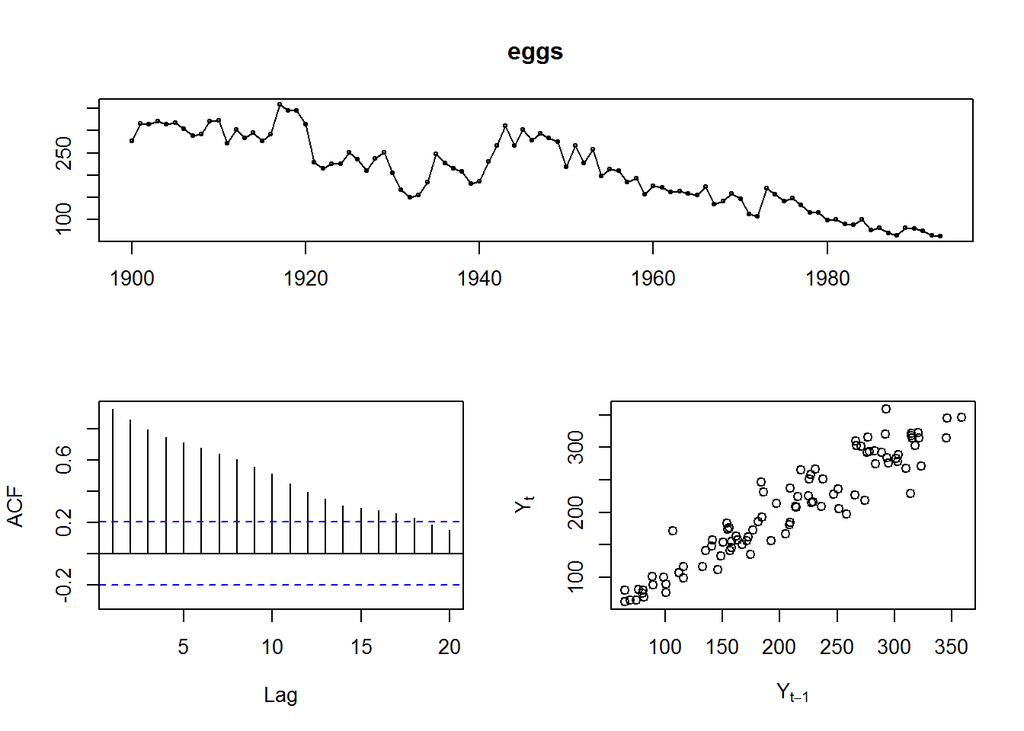

```r
tsdisplay(eggs, plot.type="scatter") # pastebimas mažėjimo trendas
```

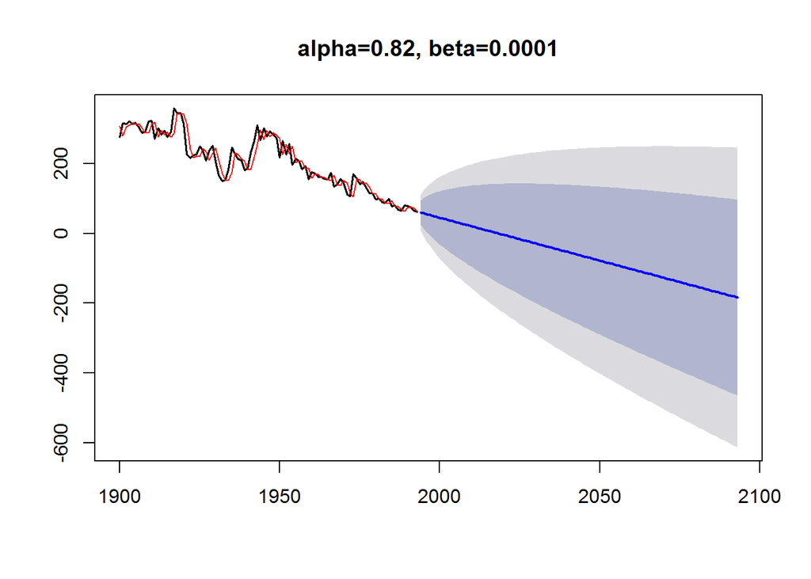

```r
fit1 <- holt(eggs, h=100)
#fit1$model
plot(fit1, lwd=1.5, main="alpha=0.82, beta=0.0001")
lines(fitted(fit1), col="red")
```

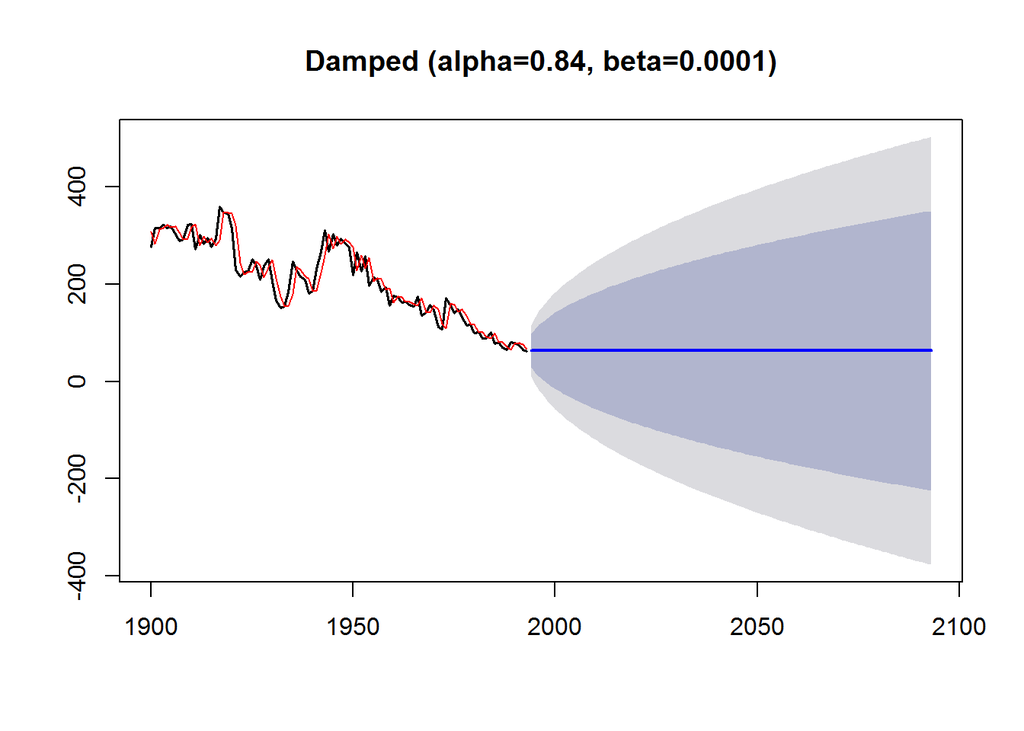

```r
fit2 <- holt(eggs, h=100, damped=TRUE)
plot(fit2, lwd=1.5, main="Damped (alpha=0.84, beta=0.0001)")
lines(fitted(fit2), col="red")
```

Grafike - rekomenduojama prognozė su damped trendo metodu

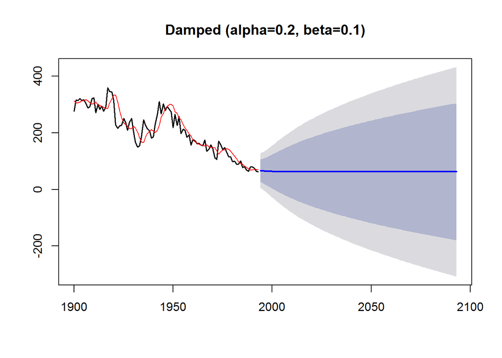

```r
fit2_1 <- holt(eggs, h=100, damped=TRUE, alpha=0.2)
plot(fit2_1, lwd=1.5, main="Damped (alpha=0.2, beta=0.1)")
lines(fitted(fit2_1), col="red")
```

Smarkiai sumažinus alpha ir truputį padidinus beta matoma, kad duomenys labiau suglodinami, o prognozė išlieka beveik nepakitusi.

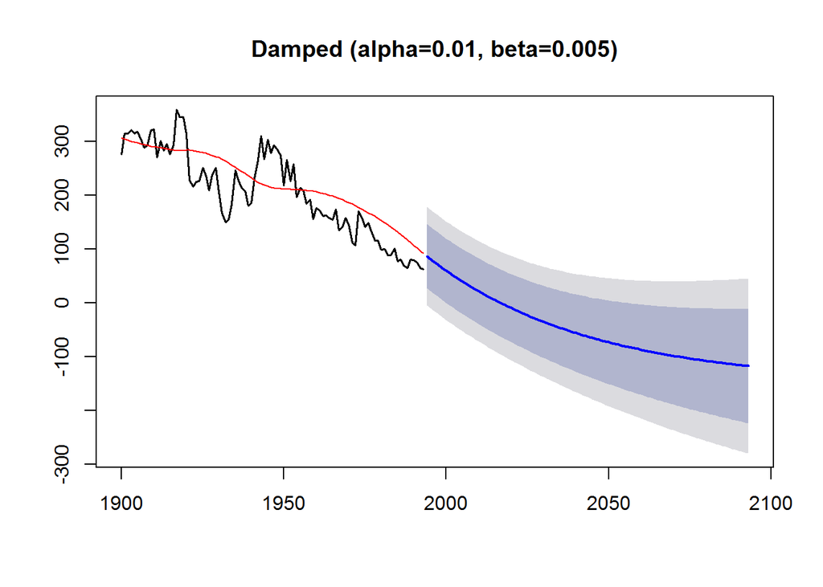

```r
fit2_2 <- holt(eggs, h=100, damped=TRUE, alpha=0.01)
plot(fit2_2, lwd=1.5, main="Damped (alpha=0.01, beta=0.005)")
lines(fitted(fit2_2), col="red")
```

Dar labiau sumažinus alpha linija tampa vis labiau glodesnė. Visgi pastebima, kad šiais atvejais ilgame laikotarpyje nebūtų logiška remtis damped trendo metodu, nes kainos pasiekia neigiamas reikšmes.  
Pabandysime **exponential** trendo metodą.

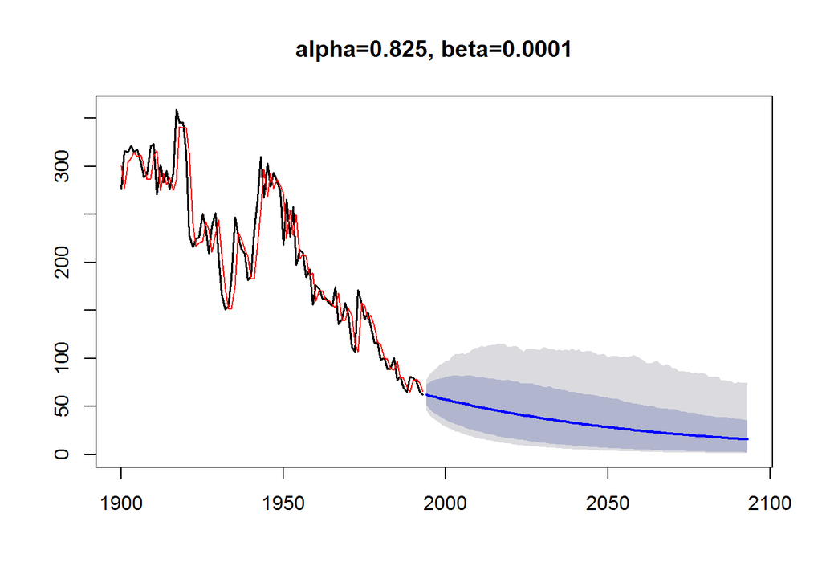

```r
fit3 <- holt(eggs, h=100, exponential=TRUE)
#fit3$model
plot(fit3, lwd=1.5, main="alpha=0.825, beta=0.0001")
lines(fitted(fit3), col="red")
```

Grafike - rekomenduojama prognozė su exponential trendo metodu. Jau prognozė atrodo logiškiau, kadangi nepasiekiamos neigiamos Y ašies reikšmės.

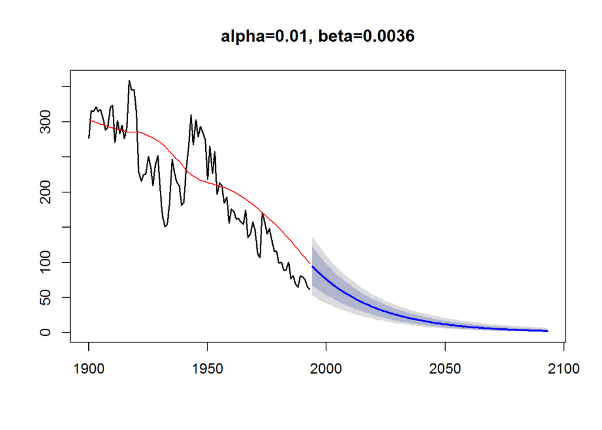

```r
fit3_1 <- holt(eggs, h=100, exponential=TRUE, alpha=0.01)
plot(fit3_1, lwd=1.5, main="alpha=0.01, beta=0.0036")
lines(fitted(fit3_1), col="red")
```

Smarkiai sumažinus alpha funkcija tapo glodesnė ir pasikliautinasis intervalas žymiai susitraukė

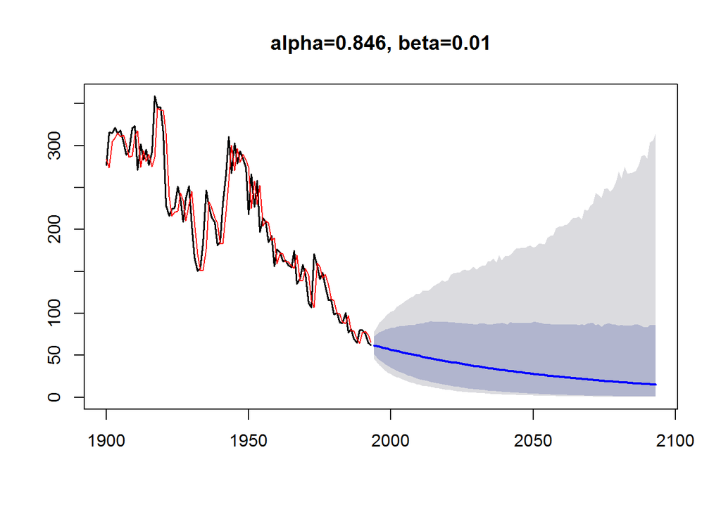

```r
fit3_2 <- holt(eggs, h=100, exponential=TRUE, beta=0.01)
plot(fit3_2, lwd=1.5, main="alpha=0.846, beta=0.01")
lines(fitted(fit3_2), col="red")
```

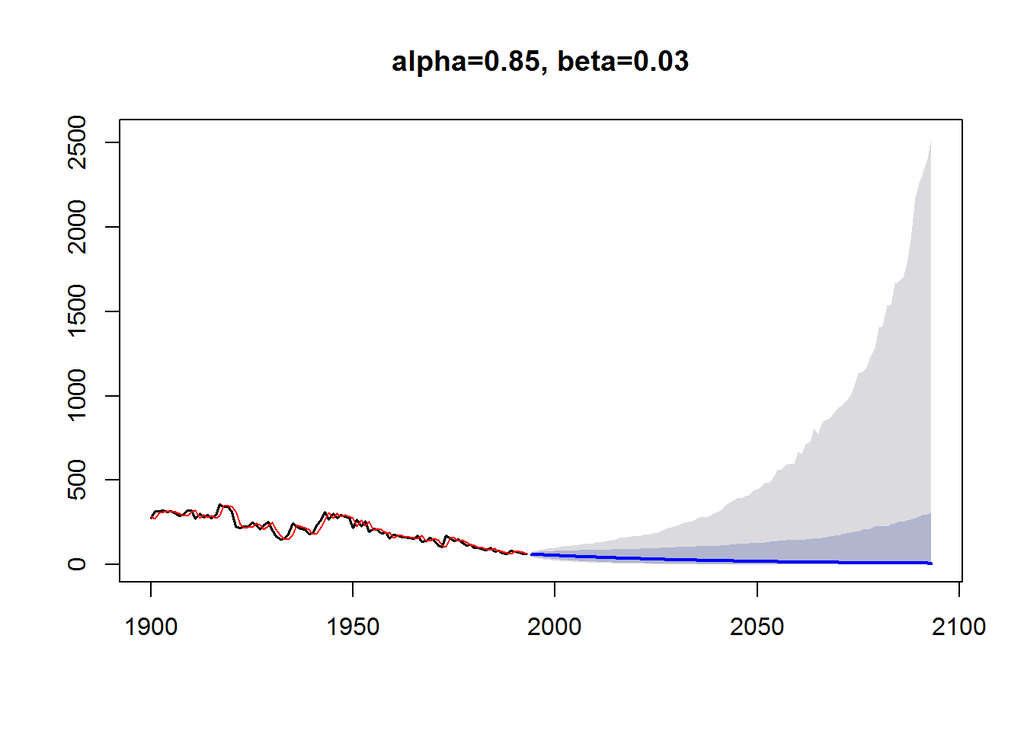

```r
fit3_3 <- holt(eggs, h=100, exponential=TRUE, beta=0.03)
plot(fit3_3, lwd=1.5, main="alpha=0.85, beta=0.03")
lines(fitted(fit3_3), col="red")
```

Iš paskutiniųjų dviejų grafikų pastebėtina, kad vos vos padidinus beta lygmenį, pasikliautinasis intervalas prasiplečia kardinaliai.

- Patikrinsime, kuris modelis duoda geriausią (t.y. mažiausią) RMSE.

```r
accuracy(fit1)[2]
```

```
## [1] 26.52594
```

```r
accuracy(fit2)[2]
```

```
## [1] 26.66343
```

```r
accuracy(fit2_1)[2]
```

```
## [1] 31.2163
```

```r
accuracy(fit2_2)[2]
```

```
## [1] 46.63393
```

```r
accuracy(fit3)[2]
```

```
## [1] 26.39044
```

```r
accuracy(fit3_1)[2]
```

```
## [1] 45.39475
```

```r
accuracy(fit3_2)[2]
```

```
## [1] 26.52404
```

```r
accuracy(fit3_3)[2]
```

```
## [1] 26.86092
```

Kaip ir buvo galima tikėtis, geriausiai pasirodė eksponentinio trendo fit3 modelis.

- Patikrinsime, ar liekanos iš geriausio modelio yra baltasis triukšmas.

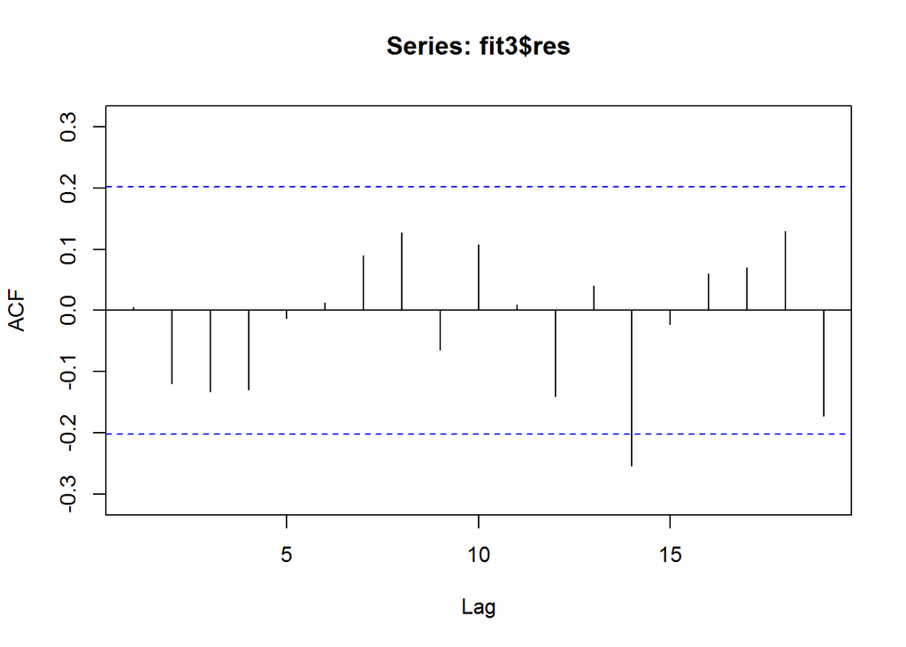

```r
Acf(fit3$res)  # grafike gana akivaizdu, kad liekanos yra baltasis triukšmas
```

```r
Box.test(fit3$res, fitdf=0, type="Lj") # formalus įsitikinimas to nepaneigia, nes p-value > 0.05
```

```
##
##  Box-Ljung test
##
## data:  fit3$res
## X-squared = 0.0021, df = 1, p-value = 0.9638
```

## 2. For this exercise, use the monthly Australian short-term overseas visitors data, May 1985–April 2005. (Data set: visitors.)

**(a) Make a time plot of your data and describe the main features of the series.**

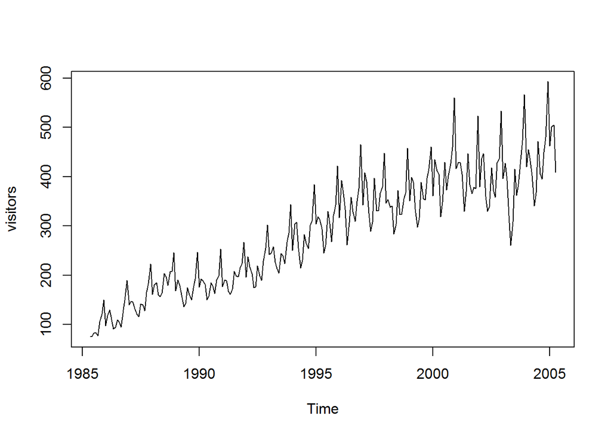

```r
plot(visitors)
```

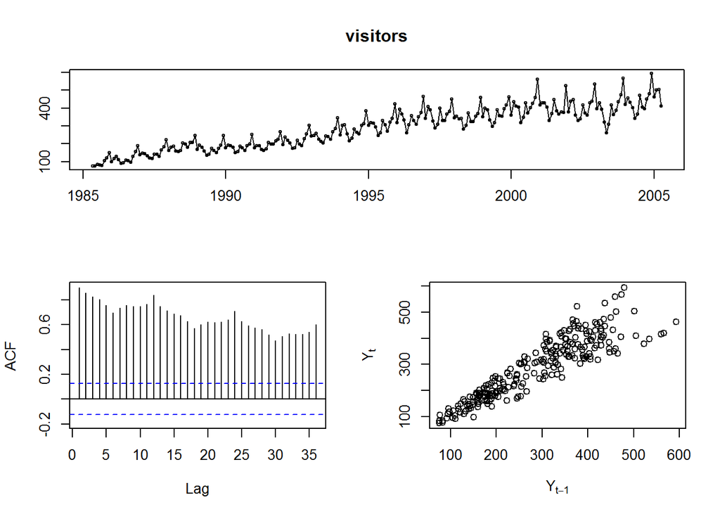

```r
tsdisplay(visitors, plot.type="scatter")
```

Iš grafikų pastebima, kad duomenys turi ryškų kasmetinį sezoniškumą bei kylantį trendą.

**(b) Forecast the next two years using Holt-Winters’ multiplicative method.**

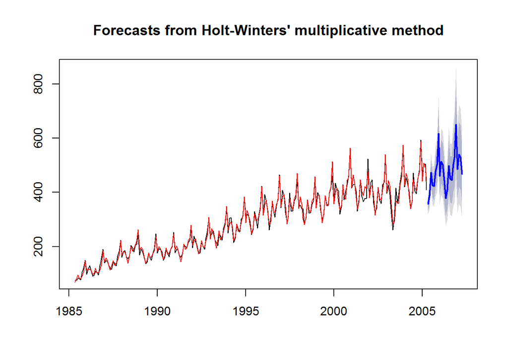

```r
progn <- hw(visitors, seasonal="multiplicative", h=24) # h - mėnesis
plot(progn)
lines(progn$fitted, col="red")
```

**(c) Why is multiplicative seasonality necessary here?**

Todėl, kad multiplikatyvus metodas naudojamas, kai sezono svyravimai nėra pastovūs, o čia laikui bėgant įgijamų reikšmių diapazonas plečiasi.

**(d) Experiment with making the trend exponential and/or damped.**

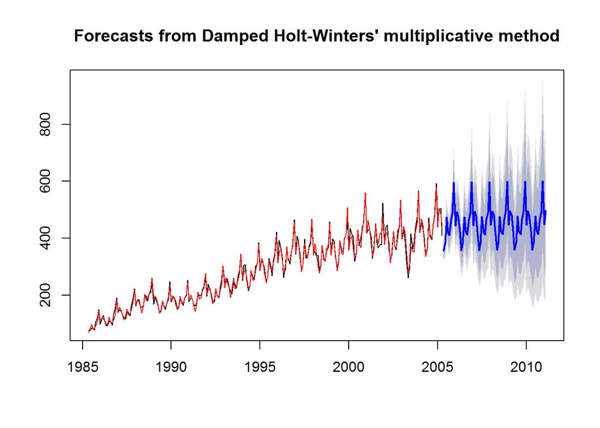

```r
progndam <- hw(visitors, seasonal="multiplicative", h=70, damped=TRUE)
plot(progndam)
lines(progndam$fitted, col="red")
```

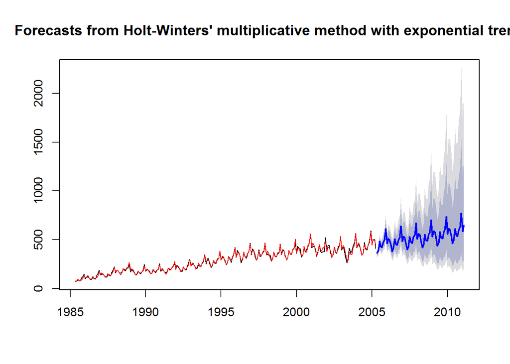

```r
prognexp <- hw(visitors, seasonal="multiplicative", h=70, exponential=TRUE)
plot(prognexp)
lines(prognexp$fitted, col="red")
```

Pastebėtina, kad damped, priešingai nei exponential, prognozėje nerodo tolimesnio augimo.

**(e) Compare the RMSE of the one-step forecasts from the various methods. Which do you prefer?**

```r
accuracy(progn)[2]
```

```
## [1] 14.52211
```

```r
accuracy(progndam)[2]
```

```
## [1] 14.40219
```

```r
accuracy(prognexp)[2]
```

```
## [1] 14.6899
```

Pagal RMSE reikėtų rinktis damped metodą.

**(f) Check that the residuals from the best model look like white noise.**

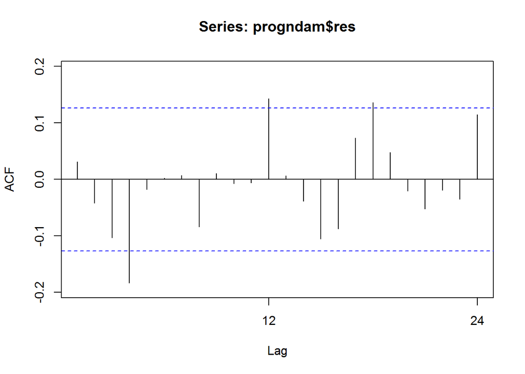

```r
Acf(progndam$res)  # nors keli stulpeliai nežymiai kerta pasikliautinąjį intervalą, tačiau tikėtina, kad liekanos yra baltasis triukšmas
```

```r
Box.test(progndam$res, fitdf=0, type="Lj") # formalus įsitikinimas to nepaneigia
```

```
##
##  Box-Ljung test
##
## data:  progndam$res
## X-squared = 0.2365, df = 1, p-value = 0.6267
```